# Lecture 9: idea for a new running example

Health insurance costs per insured person, by canton, 1997-2024

## The idea in one paragraph

Replace `swiss` with real data: gross benefits (Bruttoleistungen) of mandatory health insurance (OKP) per insured person, by canton of residence and sex, 1997-2024 (BAG, MOKKE, Tabelle 1 b). The same dataset carries the whole lecture: **(1) are the data right?** (IDA), **(2) what do they say?** (EDA with `group_by()` + `summarise()`), **(3) calculations within groups** (`lag()`, index, ratios), **(4) from summaries to tables** (`gt`), and then the ggplot part in L10.

`lag()` does not need its own slot: it appears first as an IDA tool (flag implausible jumps), then again as an EDA tool (growth rates).

> Data file: bh_total_kt_de.xlsx is at the repo root for now; it probably belongs in data/.

```r
library(tidyverse)
library(readxl)
library(gt)
library(gtExtras)
```

## 0. Import: the file is not tidy

The sheet holds **three tables stacked on top of each other** (Total, Männer, Frauen), each wide (one column per year), with a title row, empty rows, a footnote, and `CH` mixed in with the cantons. A good short recap of L7/L8 (`pivot_longer()`, `fill()`, types).

```r
raw <- read_excel("../../bh_total_kt_de.xlsx", col_names = FALSE,
                  .name_repair = "minimal")
raw[1:6, 1:5]
```

```
# A tibble: 6 × 5
  ``                                                     ``       ``    ``    ``
  <chr>                                                  <chr> <dbl> <dbl> <dbl>
1 Tabelle 1 b Alle Kostengruppen: Bruttoleistung pro ve… <NA>    NA    NA    NA
2 <NA>                                                   Total   NA    NA    NA
3 Kanton                                                 1997  1998  1999  2000
4 <NA>                                                   <NA>    NA    NA    NA
5 CH                                                     1885… 1937. 2059. 2197.
6 ZH                                                     1891… 1990. 2091. 2210.
```

```r
names(raw) <- c("canton", 1997:2024)

costs <- raw |>
  # the title row of each block says which group follows
  mutate(sex = case_when(
    str_detect(canton, fixed("(Total)"))  ~ "total",
    str_detect(canton, fixed("(Männer)")) ~ "men",
    str_detect(canton, fixed("(Frauen)")) ~ "women"
  )) |>
  fill(sex) |>
  filter(str_detect(canton, "^[A-Z]{2}$")) |>       # keep CH + 26 cantons
  mutate(across(-c(canton, sex), as.numeric)) |>    # 1997 was read as text
  pivot_longer(`1997`:`2024`, names_to = "year", values_to = "cost_pc") |>
  mutate(year = as.integer(year))

glimpse(costs)
```

```
Rows: 2,268
Columns: 4
$ canton  <chr> "CH", "CH", "CH", "CH", "CH", "CH", "CH", "CH", "CH", "CH", "C…
$ sex     <chr> "total", "total", "total", "total", "total", "total", "total",…
$ year    <int> 1997, 1998, 1999, 2000, 2001, 2002, 2003, 2004, 2005, 2006, 20…
$ cost_pc <dbl> 1885.30, 1936.58, 2058.75, 2197.32, 2295.30, 2363.63, 2475.06,…
```

> Teaching moment: without the `as.numeric()` line, `pivot_longer()` fails with *“Can’t combine `1997` and `1998` ”*, because the header row “Total” sits in the 1997 column. Real files do this.

A small lookup table so non-Swiss students get a meaningful grouping (language region by majority language; BE and GR counted as German, FR and VS as French). Joining it is a recap of L8.

```r
cantons <- tribble(
  ~canton, ~region,
  "ZH","German", "BE","German", "LU","German", "UR","German", "SZ","German",
  "OW","German", "NW","German", "GL","German", "ZG","German", "FR","French",
  "SO","German", "BS","German", "BL","German", "SH","German", "AR","German",
  "AI","German", "SG","German", "GR","German", "AG","German", "TG","German",
  "TI","Italian","VD","French", "VS","French", "NE","French", "GE","French",
  "JU","French"
)

costs <- costs |> left_join(cantons, join_by(canton))
```

## 1. Are the data right? (IDA as step 1 of EDA)

*“The first thing to do with data is to look at them.”* (Crowder & Hand, 1990)

### What does one row represent?

```r
costs |> count(sex)            # 27 units x 28 years = 756 per group
```

```
# A tibble: 3 × 2
  sex       n
  <chr> <int>
1 men     756
2 total   756
3 women   756
```

```r
costs |> count(canton) |> head(3)
```

```
# A tibble: 3 × 2
  canton     n
  <chr>  <int>
1 AG        84
2 AI        84
3 AR        84
```

`CH` is **not a canton**: it is the national total. Keep it, but never average it together with the cantons.

```r
costs |>
  filter(sex == "total", year %in% c(1997, 2024)) |>
  summarise(
    ch_official   = cost_pc[canton == "CH"],
    mean_cantons  = mean(cost_pc[canton != "CH"]),
    .by = year
  )
```

```
# A tibble: 2 × 3
   year ch_official mean_cantons
  <int>       <dbl>        <dbl>
1  1997       1885.        1764.
2  2024       4694.        4506.
```

The unweighted mean of the cantons is lower than the Swiss figure: Appenzell Innerrhoden counts as much as Zurich. Good discussion question: *which number would you report, and why?*

### Ranges and missing values

```r
costs |>
  summarise(
    n         = n(),
    n_missing = sum(is.na(cost_pc)),
    min       = min(cost_pc),
    max       = max(cost_pc),
    .by = sex
  )
```

```
# A tibble: 3 × 5
  sex       n n_missing   min   max
  <chr> <int>     <int> <dbl> <dbl>
1 total   756         0 1129. 5854.
2 men     756         0  978. 5251.
3 women   756         0 1286. 6488.
```

No `NA`s here, so the L8 missing-values examples still need a home (warm-up or exercise). Women cost more than men in every canton: plausible (maternity, longer life), worth one sentence.

### Implausible jumps: first use of `lag()`

```r
jumps <- costs |>
  filter(canton != "CH", sex == "total") |>
  arrange(canton, year) |>
  mutate(growth = cost_pc / lag(cost_pc) - 1, .by = canton) |>
  filter(abs(growth) > 0.10) |>
  arrange(desc(abs(growth)))

jumps
```

```
# A tibble: 17 × 6
   canton sex    year cost_pc region growth
   <chr>  <chr> <int>   <dbl> <chr>   <dbl>
 1 BE     total  2004   2880. German  0.154
 2 NW     total  2012   2809. German  0.144
 3 AR     total  2000   1735. German  0.125
 4 AI     total  1999   1336. German  0.123
 5 AI     total  2000   1498. German  0.121
 6 ZG     total  2007   2413. German  0.120
 7 AR     total  2012   2880. German  0.120
 8 FR     total  1998   1834. French -0.119
 9 GL     total  2000   1921. German  0.116
10 BS     total  1999   2925. German  0.114
11 OW     total  2012   2780. German  0.107
12 SG     total  2012   2979. German  0.107
13 LU     total  2004   2207. German  0.105
14 GL     total  2012   3076. German  0.104
15 AI     total  2008   2102. German  0.102
16 UR     total  2000   1736. German  0.101
17 BE     total  2000   2168. German  0.100
```

What students find (good for discussion, none needs Swiss knowledge):

- **Fribourg 1998: costs fall by 12%.** Health costs almost never fall: suspicious 1997 value or a change in reporting.
- **2012: several central/eastern cantons jump by 10-15% (NW, AR, OW, SG, GL).** Several cantons moving in the same year points to a system change, not to sicker people (I believe the new hospital financing / SwissDRG started in 2012; please check). 1999/2000 shows a similar cluster.
- **Bern 2004: +15%.** Same question (TARMED was introduced around 2004; check).
- **The footnote:** data are by treatment year, with billing delays, so the **latest year can still be revised**. Ask: should we trust 2024 as much as 2015?

> This is the place for your own experience: a jump in a series that turned out to be a definition change.

## 2. What do the data say? Summary statistics with `group_by()` + `summarise()`

### By canton, over time

```r
costs |>
  filter(sex == "total", canton != "CH") |>
  group_by(canton) |>
  summarise(
    mean   = mean(cost_pc),
    median = median(cost_pc),
    min    = min(cost_pc),
    max    = max(cost_pc)
  ) |>
  arrange(desc(max)) |>
  head(5)
```

```
# A tibble: 5 × 5
  canton  mean median   min   max
  <chr>  <dbl>  <dbl> <dbl> <dbl>
1 TI     3749.  3551. 2258. 5854.
2 GE     4149.  4031. 2842. 5721.
3 BS     4153.  4303. 2590. 5618.
4 BL     3495.  3430. 1919. 5286.
5 NE     3516.  3219. 2242. 5189.
```

### By language region and sex, in 2024

```r
costs |>
  filter(year == 2024, canton != "CH") |>
  summarise(
    mean_cost  = mean(cost_pc),
    n_cantons  = n(),
    .by = c(region, sex)
  ) |>
  arrange(sex, desc(mean_cost))
```

```
# A tibble: 9 × 4
  region  sex   mean_cost n_cantons
  <chr>   <chr>     <dbl>     <int>
1 Italian men       5251.         1
2 French  men       4414.         6
3 German  men       3876.        19
4 Italian total     5854.         1
5 French  total     5004.         6
6 German  total     4277.        19
7 Italian women     6426.         1
8 French  women     5579.         6
9 German  women     4682.        19
```

Look at `n_cantons`: the “Italian” mean is one canton (TI), and every mean is unweighted (AI counts as much as ZH). Good reason to always report `n()` next to a mean.

A natural place for `.by` vs `group_by()` (reminder from L8): same result, but `group_by()` stays until `ungroup()`.

### Many statistics at once with `across()`

```r
costs |>
  filter(sex == "total", canton != "CH", year %in% c(1997, 2024)) |>
  summarise(across(cost_pc, list(mean = mean, sd = sd, min = min, max = max)),
            .by = year)
```

```
# A tibble: 2 × 5
   year cost_pc_mean cost_pc_sd cost_pc_min cost_pc_max
  <int>        <dbl>      <dbl>       <dbl>       <dbl>
1  1997        1764.       440.       1129.       2905.
2  2024        4506.       665.       3405.       5854.
```

The spread (sd) grows with the level. Leads to a question for the index: *do cantons converge?*

## 3. Calculations within groups: `group_by()` + `mutate()`

### Growth rates (second use of `lag()`)

```r
ch <- costs |>
  filter(canton == "CH", sex == "total") |>
  mutate(growth = 100 * (cost_pc / lag(cost_pc) - 1))

ch |> filter(year >= 2018)
```

```
# A tibble: 7 × 6
  canton sex    year cost_pc region growth
  <chr>  <chr> <int>   <dbl> <chr>   <dbl>
1 CH     total  2018   3886. <NA>    0.917
2 CH     total  2019   3993. <NA>    2.73
3 CH     total  2020   3972. <NA>   -0.504
4 CH     total  2021   4233. <NA>    6.55
5 CH     total  2022   4376. <NA>    3.39
6 CH     total  2023   4516. <NA>    3.20
7 CH     total  2024   4694. <NA>    3.93
```

COVID shows up clearly: **2020 is the only year costs fell (-0.5%), followed by +6.5% in 2021** (postponed treatments). Good story for the L10 line chart.

### Index to a base year (1997 = 100)

```r
indexed <- costs |>
  filter(sex == "total") |>
  mutate(index = 100 * cost_pc / cost_pc[year == 1997], .by = canton)

indexed |>
  filter(year == 2024) |>
  arrange(desc(index)) |>
  select(canton, region, cost_pc, index) |>
  slice(c(1:3, (n() - 2):n()))      # fastest and slowest growth
```

```
# A tibble: 6 × 4
  canton region cost_pc index
  <chr>  <chr>    <dbl> <dbl>
1 AI     German   3405.  302.
2 NW     German   3827.  300.
3 AR     German   4110.  293.
4 VD     French   5166.  213.
5 FR     French   4381.  210.
6 GE     French   5721.  197.
```

Levels and growth tell different stories: the cheapest cantons in 1997 (AI, NW, AR) tripled, Geneva “only” doubled. So cantons converge in relative terms, while the sd in CHF (previous section) grew from 440 to 665. Nice discussion: *converging or diverging? It depends on the measure.*

### Women/men ratio (recap `pivot_wider()`)

```r
costs |>
  filter(year == 2024, sex != "total") |>
  pivot_wider(names_from = sex, values_from = cost_pc) |>
  mutate(ratio = women / men) |>
  arrange(desc(ratio)) |>
  head(5)
```

```
# A tibble: 5 × 6
  canton  year region   men women ratio
  <chr>  <int> <chr>  <dbl> <dbl> <dbl>
1 GE      2024 French 4903. 6488.  1.32
2 VD      2024 French 4500. 5811.  1.29
3 BS      2024 German 4915. 6290.  1.28
4 NE      2024 French 4564. 5797.  1.27
5 ZG      2024 German 3434. 4337.  1.26
```

## 4. From summaries to tables

```r
tab <- costs |>
  filter(sex == "total", canton != "CH") |>
  arrange(year) |>
  summarise(
    region     = first(region),
    cost_1997  = cost_pc[year == 1997],
    cost_2024  = cost_pc[year == 2024],
    trend      = list(cost_pc),
    .by = canton
  ) |>
  mutate(growth = cost_2024 / cost_1997 - 1) |>
  arrange(desc(cost_2024)) |>
  slice(c(1:5, 22:26))

tab |>
  gt() |>
  fmt_number(c(cost_1997, cost_2024), decimals = 0, sep_mark = "'") |>
  fmt_percent(growth, decimals = 0) |>
  gt_plt_sparkline(trend) |>
  cols_label(canton = "Canton", region = "Language region",
             cost_1997 = "CHF 1997", cost_2024 = "CHF 2024",
             growth = "Growth", trend = "1997-2024") |>
  tab_header(title = "Health insurance costs per insured person",
             subtitle = "Five most and five least expensive cantons in 2024") |>
  tab_source_note("Source: BAG, MOKKE, Tabelle 1 b (gross benefits, OKP).")
```

Health insurance costs per insured person

Five most and five least expensive cantons in 2024

| Canton | Language region | CHF 1997 | CHF 2024 | 1997-2024 | Growth |
| --- | --- | --- | --- | --- | --- |
| TI | Italian | 2'258 | 5'854 |  | 159% |
| GE | French | 2'905 | 5'721 |  | 97% |
| BS | German | 2'590 | 5'618 |  | 117% |
| BL | German | 1'919 | 5'286 |  | 176% |
| NE | French | 2'242 | 5'189 |  | 131% |
| ZG | German | 1'393 | 3'875 |  | 178% |
| NW | German | 1'277 | 3'827 |  | 200% |
| OW | German | 1'396 | 3'731 |  | 167% |
| UR | German | 1'426 | 3'676 |  | 158% |
| AI | German | 1'129 | 3'405 |  | 202% |

Source: BAG, MOKKE, Tabelle 1 b (gross benefits, OKP).

This replaces the `swiss_summary` + `round()` + `format()` slides with one table students would actually want to show.

## 5. Teaser for L10 (ggplot)

Questions the plots can answer, all on the same data:

1. **Line chart, index 1997 = 100**, one line per canton, `CH` highlighted: do cantons converge? Where is 2012, where is COVID?
2. **Facets by language region**: is the French-speaking “cost gap” a level effect or a growth effect?
3. **Women vs men** scatter (one point per canton): who is above the 45° line?
4. **Distribution in 2024** (histogram or dot plot): two bin widths, where is Geneva?

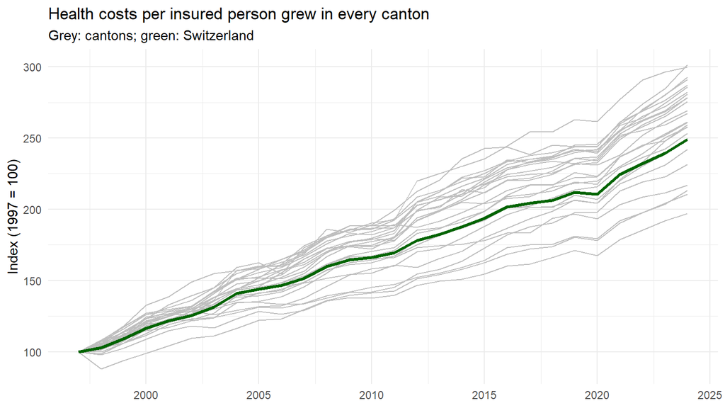

```r
indexed |>
  ggplot(aes(year, index, group = canton)) +
  geom_line(colour = "grey75") +
  geom_line(data = filter(indexed, canton == "CH"), colour = "darkgreen",
            linewidth = 1.2) +
  labs(x = NULL, y = "Index (1997 = 100)",
       title = "Health costs per insured person grew in every canton",
       subtitle = "Grey: cantons; green: Switzerland") +
  theme_minimal()
```

## Open points for you

- Check the two events I attributed from memory (2012 hospital financing, 2004 TARMED) before saying them in class.
- Fribourg 1997: worth a look in the BAG documentation (Einstiegstext on billing delays).
- No missing values in this file: decide where the skipped L8 missing-values examples go.
- Exercise idea: same analysis with another BAG table (e.g. one cost group: hospital, doctors, drugs), or a comparison with the student’s home country (OECD).